# Graphing and Interpreting Data — Student Notes

**Unit: Math in Science — Lesson 02** Name: _______________________ Date: __________ Period: ____

## Learning Targets

By the end of today’s 42 minutes I can:

- Identify the independent and dependent variable and put each on the correct axis.
- Draw a line of best fit and explain why it beats connect-the-dots.
- Calculate a slope (rise / run) with units and say what it means.

## Key Vocabulary

- **independent variable** — _______________________________________________
- **dependent variable** — _______________________________________________
- **slope** — _______________________________________________

## Guided Notes

**Which axis?** The variable I *choose* (the __________ variable) goes on the __________-axis. The variable that *responds* and I measure (the __________ variable) goes on the __________-axis.

**Line of best fit:** a single straight line drawn close to as many points as possible, with about equal points __________ and below it. It is NOT __________-to-__________, because that would treat measurement error as real.

**Slope:** slope = rise / run = Δy / Δ__________ . Always include __________ (e.g., cm per gram). When a line is straight through the origin, the slope is the __________ constant.

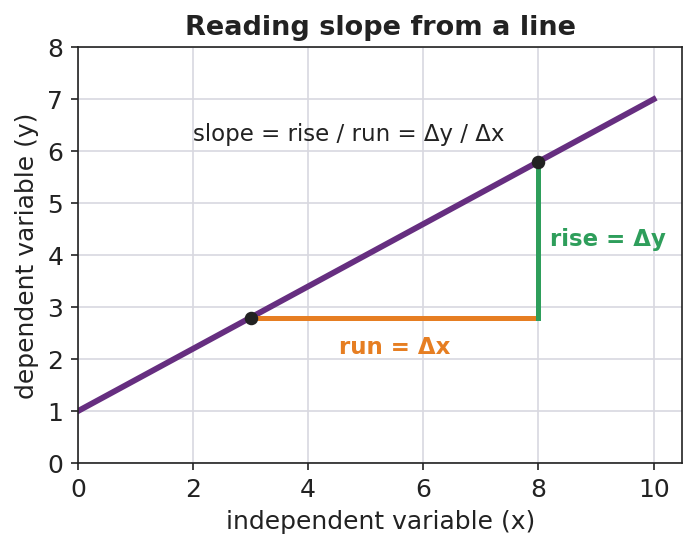

Reading slope from a line

## Worked Example

**Problem.** Lid data gives a straight line through the origin. Between two points, the circumference rises 31.4 cm while the diameter runs 10.0 cm. Find the slope and interpret it.

**Solution.** 1. slope = rise / run = 31.4 cm / __________ cm. 2. slope = __________ (no length unit left — cm / cm cancels). 3. The line passes through the __________, so this slope is the proportionality constant: C = __________ × d. 4. That constant ≈ 3.14, which is __________. So C = πd.

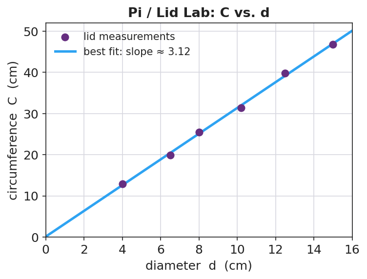

Pi / Lid Lab: circumference vs. diameter

## Summary

Finish the sentence (Because / But / So):

> A straight-line graph through the origin shows a proportional relationship because __________________________________________, but __________________________________________, so __________________________________________.